# project

**Load Dataset**

```python
import pandas as pd
import matplotlib.pyplot as plt
import seaborn as sns
df = pd.read_csv("/Users/abhinavpawar/Downloads/Financial_Fraud_Detection_dataset/cc_data.csv")
```

```python
df.head()
```

|  | index | trans_date_trans_time | cc_num | merchant | category | amt | first | last | gender | street | ... | lat | long | city_pop | job | dob | trans_num | unix_time | merch_lat | merch_long | is_fraud |
| --- | --- | --- | --- | --- | --- | --- | --- | --- | --- | --- | --- | --- | --- | --- | --- | --- | --- | --- | --- | --- | --- |
| 0 | 151888 | 2019-03-23 | 3586008444788260 | fraud_Ferry, Lynch and Kautzer | misc_net | 1.24 | Crystal | Fuller | F | 000 Jennifer Mills | ... | 47.4974 | -122.0107 | 50489 | Osteopath | 29/02/84 | ff66e2310bf7a2a05e65d6b0a363aa5b | 1332471978 | 47.352172 | -121.644080 | 0 |
| 1 | 1185025 | 2020-05-10 | 4671727014157740 | fraud_Bogisich Inc | grocery_pos | 112.57 | Kenneth | Edwards | M | 3653 Ryan Crossroad | ... | 40.8618 | -85.6067 | 2304 | Retail banker | 25/07/55 | f1edcfa2102065f5f76375c2d20b9081 | 1368185292 | 40.265726 | -85.914050 | 0 |
| 2 | 10818 | 2019-01-07 | 377993105397617 | fraud_Mohr-Bayer | shopping_net | 6.69 | Nathan | Martinez | M | 586 Thomas Cliffs | ... | 44.8755 | -88.1555 | 5548 | Mining engineer | 11/09/75 | 0caa0ca338d1d2903b92bb42d8905768 | 1325943086 | 44.512954 | -88.693464 | 0 |
| 3 | 975275 | 2020-01-30 | 4710826438164840000 | fraud_Langworth LLC | personal_care | 100.69 | Juan | Henry | M | 9795 Lori Island Suite 346 | ... | 48.8328 | -108.3961 | 192 | Further education lecturer | 04/01/64 | c7d25a5388311ebd7f2eef77459376ac | 1359571786 | 47.909634 | -109.008657 | 0 |
| 4 | 346814 | 2019-06-12 | 372382441451095 | fraud_Hills-Witting | shopping_net | 7.80 | Brent | Terrell | M | 502 Rice Plaza Apt. 979 | ... | 41.8948 | -73.9767 | 2471 | Heritage manager | 21/01/66 | 8e1306b47052ac10fe48512de79edf71 | 1339470288 | 41.534838 | -74.449927 | 0 |

5 rows × 23 columns

**What are the dimensions (number of rows and columns) of the dataset?**

```python
rows, columns = df.shape
print("Number of rows:", rows)
print("Number of columns:", columns)
```

```
Number of rows: 389002
Number of columns: 23
```

**2. Unique Values in Categorical Variables**

```python
for col in df.select_dtypes(include='object').columns:
    print(f"{col:<25} | Unique values: {df[col].nunique()}")
```

```
trans_date_trans_time     | Unique values: 537
merchant                  | Unique values: 693
category                  | Unique values: 14
first                     | Unique values: 352
last                      | Unique values: 481
gender                    | Unique values: 2
street                    | Unique values: 979
city                      | Unique values: 890
state                     | Unique values: 51
job                       | Unique values: 492
dob                       | Unique values: 964
trans_num                 | Unique values: 389002
```

**3. Distribution of Numerical Variables**

```python
numerical_cols = df.select_dtypes(include=['int64', 'float64']).columns
numerical_cols = numerical_cols.drop(['cc_num'])

print("Numerical Columns:")
print(numerical_cols)
```

```
Numerical Columns:
Index(['index', 'amt', 'zip', 'lat', 'long', 'city_pop', 'unix_time',
       'merch_lat', 'merch_long', 'is_fraud'],
      dtype='object')
```

```python
df[numerical_cols].describe()
```

|  | index | amt | zip | lat | long | city_pop | unix_time | merch_lat | merch_long | is_fraud |
| --- | --- | --- | --- | --- | --- | --- | --- | --- | --- | --- |
| count | 3.890020e+05 | 389002.000000 | 389002.000000 | 389002.000000 | 389002.000000 | 3.890020e+05 | 3.890020e+05 | 389002.000000 | 389002.000000 | 389002.000000 |
| mean | 6.485205e+05 | 70.442148 | 48818.064295 | 38.533121 | -90.237664 | 8.868084e+04 | 1.349251e+09 | 38.531683 | -90.236674 | 0.005789 |
| std | 3.745744e+05 | 162.203915 | 26879.383224 | 5.074596 | 13.745855 | 3.012101e+05 | 1.285085e+07 | 5.109400 | 13.757311 | 0.075866 |
| min | 1.100000e+01 | 1.000000 | 1257.000000 | 20.027100 | -165.672300 | 2.300000e+01 | 1.325376e+09 | 19.029798 | -166.669638 | 0.000000 |
| 25% | 3.241842e+05 | 9.660000 | 26237.000000 | 34.620500 | -96.798000 | 7.430000e+02 | 1.338751e+09 | 34.719394 | -96.905445 | 0.000000 |
| 50% | 6.486485e+05 | 47.570000 | 48174.000000 | 39.354300 | -87.476900 | 2.456000e+03 | 1.349267e+09 | 39.361065 | -87.446843 | 0.000000 |
| 75% | 9.735032e+05 | 83.077500 | 72011.000000 | 41.940400 | -80.158000 | 2.032800e+04 | 1.359460e+09 | 41.956012 | -80.253831 | 0.000000 |
| max | 1.296674e+06 | 27390.120000 | 99783.000000 | 66.693300 | -67.950300 | 2.906700e+06 | 1.371817e+09 | 67.064277 | -66.956540 | 1.000000 |

```python
# Skewness of numerical variables

df[numerical_cols].skew()
```

```
index         -0.001028
amt           40.273832
zip            0.080863
lat           -0.196950
long          -1.140375
city_pop       5.587892
unix_time      0.002364
merch_lat     -0.192288
merch_long    -1.137188
is_fraud      13.028560
dtype: float64
```

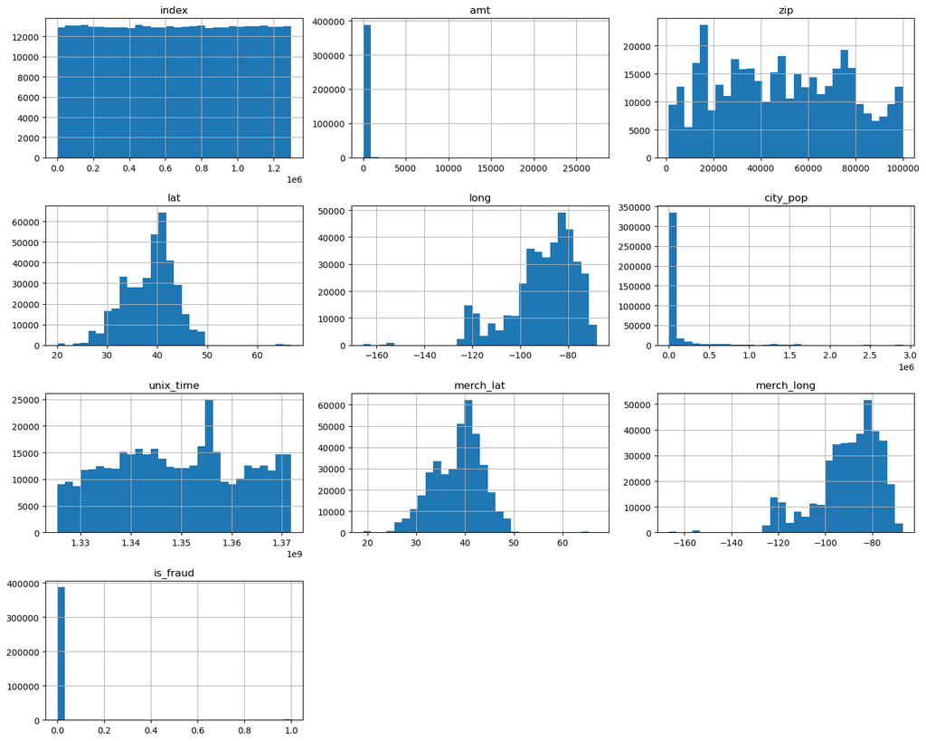

```python
df[numerical_cols].hist(figsize=(15, 12), bins=30)
plt.tight_layout()
plt.show()
```

**4. Missing Values**

```python
df.isnull().sum()
```

```
index                    0
trans_date_trans_time    0
cc_num                   0
merchant                 0
category                 0
amt                      0
first                    0
last                     0
gender                   0
street                   0
city                     0
state                    0
zip                      0
lat                      0
long                     0
city_pop                 0
job                      0
dob                      0
trans_num                0
unix_time                0
merch_lat                0
merch_long               0
is_fraud                 0
dtype: int64
```

**5. Summary Statistics**

```python
num_cols = df.select_dtypes(include=['int64', 'float64']).columns
num_cols = num_cols.drop(['cc_num'])
```

```python
summary_stats = df[num_cols].describe()
summary_stats
```

|  | index | amt | zip | lat | long | city_pop | unix_time | merch_lat | merch_long | is_fraud |
| --- | --- | --- | --- | --- | --- | --- | --- | --- | --- | --- |
| count | 3.890020e+05 | 389002.000000 | 389002.000000 | 389002.000000 | 389002.000000 | 3.890020e+05 | 3.890020e+05 | 389002.000000 | 389002.000000 | 389002.000000 |
| mean | 6.485205e+05 | 70.442148 | 48818.064295 | 38.533121 | -90.237664 | 8.868084e+04 | 1.349251e+09 | 38.531683 | -90.236674 | 0.005789 |
| std | 3.745744e+05 | 162.203915 | 26879.383224 | 5.074596 | 13.745855 | 3.012101e+05 | 1.285085e+07 | 5.109400 | 13.757311 | 0.075866 |
| min | 1.100000e+01 | 1.000000 | 1257.000000 | 20.027100 | -165.672300 | 2.300000e+01 | 1.325376e+09 | 19.029798 | -166.669638 | 0.000000 |
| 25% | 3.241842e+05 | 9.660000 | 26237.000000 | 34.620500 | -96.798000 | 7.430000e+02 | 1.338751e+09 | 34.719394 | -96.905445 | 0.000000 |
| 50% | 6.486485e+05 | 47.570000 | 48174.000000 | 39.354300 | -87.476900 | 2.456000e+03 | 1.349267e+09 | 39.361065 | -87.446843 | 0.000000 |
| 75% | 9.735032e+05 | 83.077500 | 72011.000000 | 41.940400 | -80.158000 | 2.032800e+04 | 1.359460e+09 | 41.956012 | -80.253831 | 0.000000 |
| max | 1.296674e+06 | 27390.120000 | 99783.000000 | 66.693300 | -67.950300 | 2.906700e+06 | 1.371817e+09 | 67.064277 | -66.956540 | 1.000000 |

**6. Correlation Between Variables**

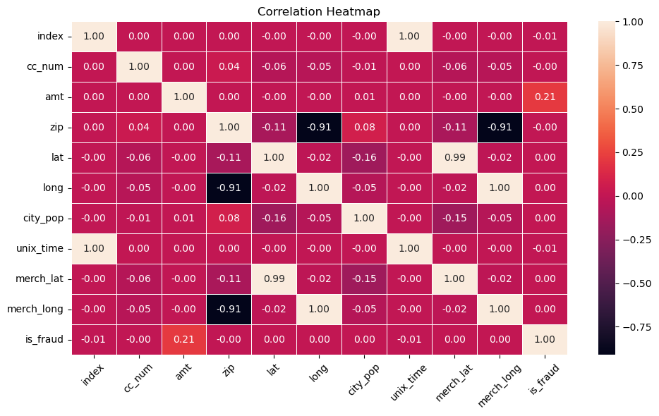

```python
corr = df.corr(numeric_only=True)

plt.figure(figsize=(10, 6))  # increase size
sns.heatmap(corr, annot=True, fmt=".2f", linewidths=0.5)

plt.title("Correlation Heatmap")
plt.xticks(rotation=45)
plt.yticks(rotation=0)
plt.tight_layout()
plt.show()
```

**7. Distribution of amt Across Fraud**

```python
df.groupby('is_fraud')['amt'].describe()
```

| is_fraud | count | mean | std | min | 25% | 50% | 75% | max |
| --- | --- | --- | --- | --- | --- | --- | --- | --- |
| 0 | 386750.0 | 67.834157 | 156.227752 | 1.00 | 9.6200 | 47.330 | 82.5000 | 27390.12 |
| 1 | 2252.0 | 518.328677 | 389.127281 | 1.18 | 147.8825 | 365.285 | 888.3425 | 1294.83 |

**8. Outlier Detection**

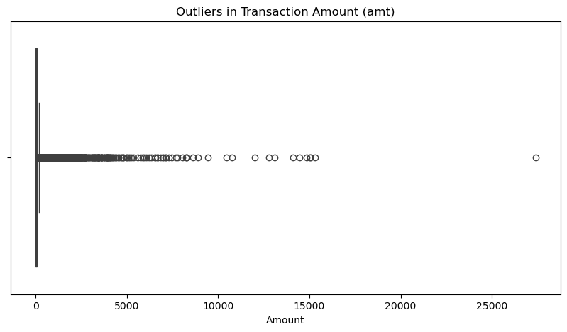

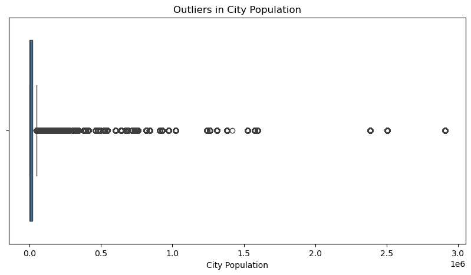

```python
plt.figure(figsize=(10,5))
sns.boxplot(x=df['amt'])
plt.title("Outliers in Transaction Amount (amt)")
plt.xlabel("Amount")
plt.show()

plt.figure(figsize=(10,5))
sns.boxplot(x=df['city_pop'])
plt.title("Outliers in City Population")
plt.xlabel("City Population")
plt.show()
```

**9. Time-based Trends**

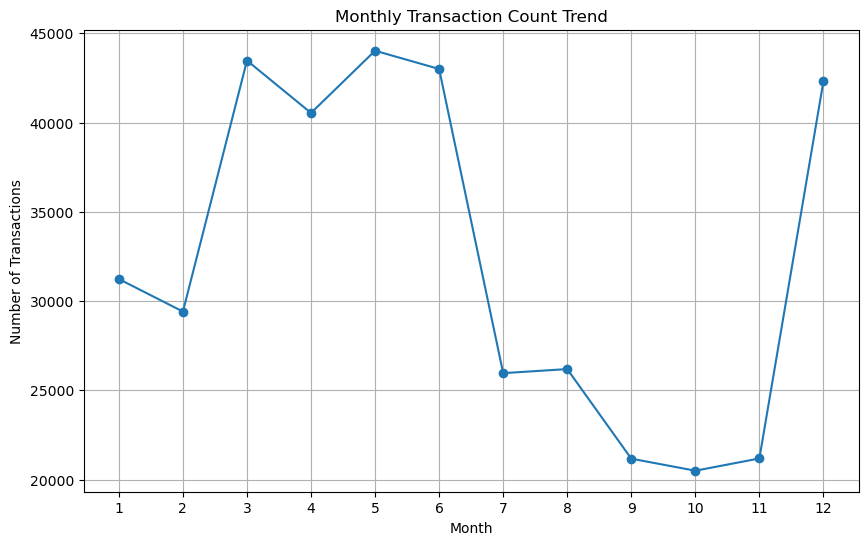

```python
df['trans_date_trans_time'] = pd.to_datetime(df['trans_date_trans_time'])

monthly_counts = df.groupby(df['trans_date_trans_time'].dt.month)['amt'].count()

plt.figure(figsize=(10,6))
monthly_counts.plot(marker='o')

plt.title("Monthly Transaction Count Trend")
plt.xlabel("Month")
plt.ylabel("Number of Transactions")
plt.xticks(range(1,13))
plt.grid()

plt.show()
```

**10. Target Variable Distribution**

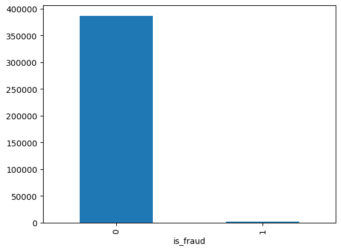

```python
df['is_fraud'].value_counts().plot(kind='bar')
plt.show()
```

**11. Unusual / Unexpected Values**

```python
df[df['amt'] > df['amt'].quantile(0.99)]
```

|  | index | trans_date_trans_time | cc_num | merchant | category | amt | first | last | gender | street | ... | lat | long | city_pop | job | dob | trans_num | unix_time | merch_lat | merch_long | is_fraud |
| --- | --- | --- | --- | --- | --- | --- | --- | --- | --- | --- | --- | --- | --- | --- | --- | --- | --- | --- | --- | --- | --- |
| 56 | 28835 | 2019-01-17 | 4642255475285940 | fraud_Nicolas, Hills and McGlynn | entertainment | 564.34 | Sabrina | Johnson | F | 320 Nicholson Orchard | ... | 38.9999 | -109.6150 | 46 | Surveyor, minerals | 23/04/87 | b8b80b56dbdf53fbe417f0915fe1d3ee | 1326840326 | 38.435536 | -109.844716 | 1 |
| 100 | 1173736 | 2020-05-04 | 4469777115158230000 | fraud_Bednar Group | misc_net | 811.06 | Gregory | Graham | M | 4005 Dana Glens | ... | 42.7280 | -71.1810 | 47249 | Market researcher | 22/11/80 | a72767d34b61073e1766658fe5b57067 | 1367706893 | 41.948021 | -70.262220 | 1 |
| 322 | 1030431 | 2020-03-02 | 4255397449664180000 | fraud_Turner LLC | travel | 5940.23 | George | Smith | M | 7377 Walton Extensions Apt. 979 | ... | 32.6900 | -96.9177 | 1263321 | Designer, interior/spatial | 27/09/52 | 0b039874472eaf1099479b79935eb3d0 | 1362263201 | 32.687989 | -96.373122 | 0 |
| 351 | 1258698 | 2020-06-07 | 6502195877055600 | fraud_Ritchie, Bradtke and Stiedemann | travel | 557.21 | Nathan | Byrd | M | 155 Gregory Mount Suite 791 | ... | 39.4584 | -106.3851 | 277 | Human resources officer | 03/04/85 | a257f7ab03ecb4fe79a64d0599c36970 | 1370647512 | 38.746512 | -106.874703 | 0 |
| 483 | 140272 | 2019-03-17 | 4069975342931680 | fraud_Baumbach, Strosin and Nicolas | shopping_pos | 827.15 | Kimberly | Martin | F | 1943 Dennis Inlet Suite 145 | ... | 38.4257 | -81.9943 | 21902 | Sub | 18/09/80 | 7e7e405ede065d430ea53678b3af7ce5 | 1331997681 | 38.146392 | -81.090307 | 0 |
| ... | ... | ... | ... | ... | ... | ... | ... | ... | ... | ... | ... | ... | ... | ... | ... | ... | ... | ... | ... | ... | ... |
| 388469 | 1029815 | 2020-03-02 | 4642894980163 | fraud_Yost, Block and Koepp | misc_pos | 1001.91 | Eddie | Mendez | M | 1831 Faith View Suite 653 | ... | 40.7491 | -95.0380 | 7297 | IT trainer | 13/07/90 | 53ab54ac93f62e291f7239ad194583dc | 1362249048 | 40.811156 | -94.935682 | 0 |
| 388491 | 246500 | 2019-05-03 | 213161869125933 | fraud_Moore, Dibbert and Koepp | misc_net | 814.80 | Monica | Lane | F | 3270 Scott Islands | ... | 44.6084 | -70.6993 | 190 | Animal nutritionist | 17/04/70 | 1f1f71ca8201a9452c9902a081d3030e | 1336082968 | 44.452708 | -71.061607 | 1 |
| 388604 | 616126 | 2019-09-19 | 4897067971111200000 | fraud_Block-Parisian | misc_net | 820.28 | Randy | Wood | M | 542 Howe Mission Apt. 092 | ... | 28.3011 | -82.6927 | 42619 | Environmental education officer | 07/10/75 | 39554efd2f18f05dc48dca4e3b0a1668 | 1348019649 | 27.402186 | -82.496122 | 1 |
| 388738 | 1222953 | 2020-05-25 | 3558652751678950 | fraud_Parisian, Schiller and Altenwerth | misc_net | 729.05 | Teresa | Blankenship | F | 6638 Lucero Mill Suite 952 | ... | 32.6205 | -94.2000 | 2807 | Chiropodist | 26/01/31 | 4da4a92c16095dcf0c9057c9964dfbec | 1369524248 | 33.229070 | -93.694563 | 1 |
| 388862 | 372504 | 2019-06-21 | 581293083266 | fraud_Bednar Inc | travel | 607.12 | William | Thomas | M | 39227 Mcpherson Shoals | ... | 36.3850 | -98.0727 | 1078 | Podiatrist | 06/10/89 | aed1d3e3d75d1e9daafc057ca6905aed | 1340303160 | 36.331688 | -98.958196 | 0 |

3891 rows × 23 columns

**12 • Are there any potential data entry errors or inconsistencies in the dataset?**

```python
df.describe(include='all')
```

|  | index | trans_date_trans_time | cc_num | merchant | category | amt | first | last | gender | street | ... | lat | long | city_pop | job | dob | trans_num | unix_time | merch_lat | merch_long | is_fraud |
| --- | --- | --- | --- | --- | --- | --- | --- | --- | --- | --- | --- | --- | --- | --- | --- | --- | --- | --- | --- | --- | --- |
| count | 3.890020e+05 | 389002 | 3.890020e+05 | 389002 | 389002 | 389002.000000 | 389002 | 389002 | 389002 | 389002 | ... | 389002.000000 | 389002.000000 | 3.890020e+05 | 389002 | 389002 | 389002 | 3.890020e+05 | 389002.000000 | 389002.000000 | 389002.000000 |
| unique | NaN | NaN | NaN | 693 | 14 | NaN | 352 | 481 | 2 | 979 | ... | NaN | NaN | NaN | 492 | 964 | 389002 | NaN | NaN | NaN | NaN |
| top | NaN | NaN | NaN | fraud_Kilback LLC | gas_transport | NaN | Christopher | Smith | F | 1652 James Mews | ... | NaN | NaN | NaN | Film/video editor | 23/03/77 | ff66e2310bf7a2a05e65d6b0a363aa5b | NaN | NaN | NaN | NaN |
| freq | NaN | NaN | NaN | 1305 | 39633 | NaN | 7982 | 8511 | 213231 | 980 | ... | NaN | NaN | NaN | 2945 | 1694 | 1 | NaN | NaN | NaN | NaN |
| mean | 6.485205e+05 | 2019-10-03 01:25:46.437293056 | 4.191512e+17 | NaN | NaN | 70.442148 | NaN | NaN | NaN | NaN | ... | 38.533121 | -90.237664 | 8.868084e+04 | NaN | NaN | NaN | 1.349251e+09 | 38.531683 | -90.236674 | 0.005789 |
| min | 1.100000e+01 | 2019-01-01 00:00:00 | 6.041621e+10 | NaN | NaN | 1.000000 | NaN | NaN | NaN | NaN | ... | 20.027100 | -165.672300 | 2.300000e+01 | NaN | NaN | NaN | 1.325376e+09 | 19.029798 | -166.669638 | 0.000000 |
| 25% | 3.241842e+05 | 2019-06-03 00:00:00 | 1.800429e+14 | NaN | NaN | 9.660000 | NaN | NaN | NaN | NaN | ... | 34.620500 | -96.798000 | 7.430000e+02 | NaN | NaN | NaN | 1.338751e+09 | 34.719394 | -96.905445 | 0.000000 |
| 50% | 6.486485e+05 | 2019-10-03 00:00:00 | 3.521417e+15 | NaN | NaN | 47.570000 | NaN | NaN | NaN | NaN | ... | 39.354300 | -87.476900 | 2.456000e+03 | NaN | NaN | NaN | 1.349267e+09 | 39.361065 | -87.446843 | 0.000000 |
| 75% | 9.735032e+05 | 2020-01-29 00:00:00 | 4.642255e+15 | NaN | NaN | 83.077500 | NaN | NaN | NaN | NaN | ... | 41.940400 | -80.158000 | 2.032800e+04 | NaN | NaN | NaN | 1.359460e+09 | 41.956012 | -80.253831 | 0.000000 |
| max | 1.296674e+06 | 2020-06-21 00:00:00 | 4.992346e+18 | NaN | NaN | 27390.120000 | NaN | NaN | NaN | NaN | ... | 66.693300 | -67.950300 | 2.906700e+06 | NaN | NaN | NaN | 1.371817e+09 | 67.064277 | -66.956540 | 1.000000 |
| std | 3.745744e+05 | NaN | 1.311579e+18 | NaN | NaN | 162.203915 | NaN | NaN | NaN | NaN | ... | 5.074596 | 13.745855 | 3.012101e+05 | NaN | NaN | NaN | 1.285085e+07 | 5.109400 | 13.757311 | 0.075866 |

11 rows × 23 columns

**13 • How does the distribution of numerical variables vary between different groups or segments of the dataset?**

```python
df.groupby('gender')['amt'].mean()
df.groupby('category')['amt'].mean()
```

```
category
entertainment      64.092672
food_dining        51.195930
gas_transport      63.399440
grocery_net        53.701064
grocery_pos       117.527055
health_fitness     54.226140
home               58.292296
kids_pets          57.602997
misc_net           82.037148
misc_pos           61.842209
personal_care      48.127007
shopping_net       88.527034
shopping_pos       79.332646
travel            114.351042
Name: amt, dtype: float64
```

**14 • What are the top factors that influence the target variable, if applicable?**

```python
corr_with_target = df.corr(numeric_only=True)['is_fraud'].sort_values(ascending=False)

print("Correlation with is_fraud:")
print(corr_with_target)
```

```
Correlation with is_fraud:
is_fraud      1.000000
amt           0.210706
lat           0.002643
merch_lat     0.002406
long          0.001376
merch_long    0.001351
city_pop      0.001176
zip          -0.001220
cc_num       -0.001280
index        -0.006121
unix_time    -0.006562
Name: is_fraud, dtype: float64
```

```python
# Fraud rate by category
fraud_category = df.groupby('category')['is_fraud'].mean().sort_values(ascending=False)

print("Fraud Rate by Category:")
print(fraud_category)
```

```
Fraud Rate by Category:
category
shopping_net      0.016317
misc_net          0.015017
grocery_pos       0.014090
shopping_pos      0.007226
gas_transport     0.004870
travel            0.003445
misc_pos          0.003202
grocery_net       0.002889
personal_care     0.002776
entertainment     0.002418
kids_pets         0.002182
home              0.001762
food_dining       0.001552
health_fitness    0.001516
Name: is_fraud, dtype: float64
```

**Python Exploratory Data Analysis (EDA)**

# 💳 Financial Fraud Detection – Python Analysis

# 📌 Introduction

Exploratory Data Analysis (EDA) was performed on the credit card transaction dataset to understand its structure, detect anomalies, identify patterns, and determine key factors influencing fraudulent transactions.

The objective is to support the development of a reliable fraud detection system for the financial industry.

# 📊 Dataset Overview

The dataset includes customer information, transaction details, merchant data, and fraud labels.

# 🔍 Key Findings from EDA

## ⚖️ Class Imbalance

- Fraudulent transactions represent a **very small proportion** of total transactions.
- This indicates a **severe class imbalance problem**.

👉 This is critical when building machine learning models, as models may become biased toward non-fraud cases.

## 💰 Transaction Amount (`amt`)

- Shows the **strongest correlation with fraud (≈ 0.21)**.
- Fraudulent transactions have **significantly higher average amounts**.
- Distribution is **highly right-skewed** with extreme outliers.

👉 **Conclusion:**  
Transaction amount is one of the **most important predictive features**.

## 🛒 Transaction Category

Certain categories show higher fraud rates:

👉 **Conclusion:**  
Transaction category is a **key factor in identifying fraud risk**.

## 🌍 Geographical Variables

- Latitude and longitude variables show **strong internal correlation**.
- City population is **highly skewed**.
- No strong correlation with fraud was observed.

👉 **Conclusion:**  
Location alone is **not a strong predictor**, but may be useful in advanced models.

## 🧹 Data Quality Checks

👉 **Conclusion:**  
The dataset is **clean and reliable for analysis**.

# 💼 Business Implications

Based on the analysis:

- High-value transactions require **stricter monitoring**.
- Online transaction categories need **enhanced fraud controls**.
- Fraud detection systems must handle **class imbalance effectively**.
- Feature engineering using **time and behavioral patterns** can improve accuracy.

# 🧾 Conclusion

The EDA process provided critical insights into fraud behavior patterns.

- **Transaction amount** and **category** emerged as the most influential factors.
- **Geographical and demographic features** showed limited direct impact.
- The dataset is **clean, structured, and suitable for predictive modeling**.

👉 These insights form a strong foundation for building a **robust fraud detection system** in the financial industry.